```r
summary(lmod2)$r.squared;summary(lmod2)$adj.r.squared
```

```
## [1] 0.7991417
```

```
## [1] 0.7905945
```

Model 3 is better then previous Models.  
q) For your best model so far, check out the plots and compare to the originals. Do they look better now?

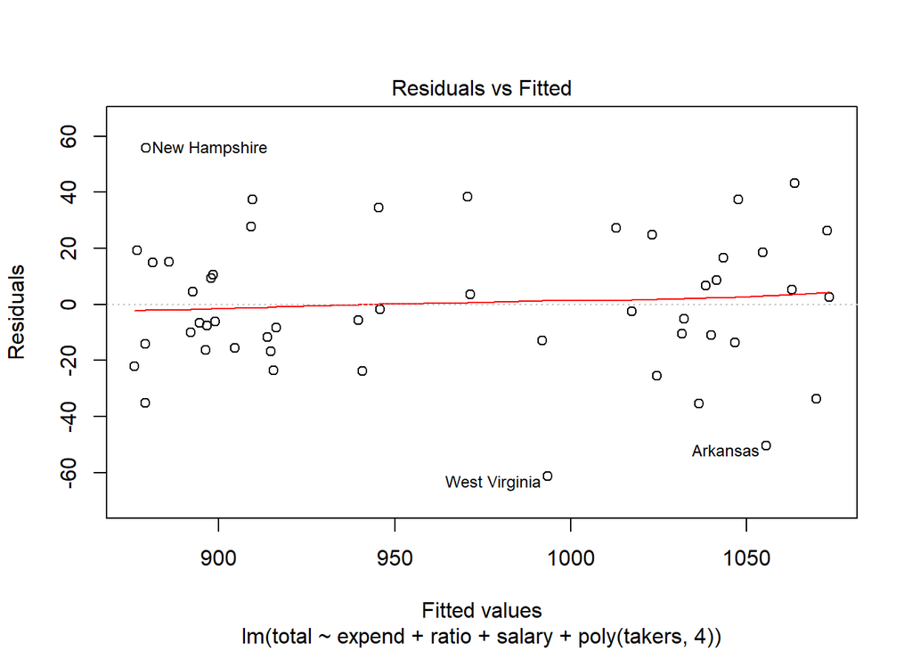

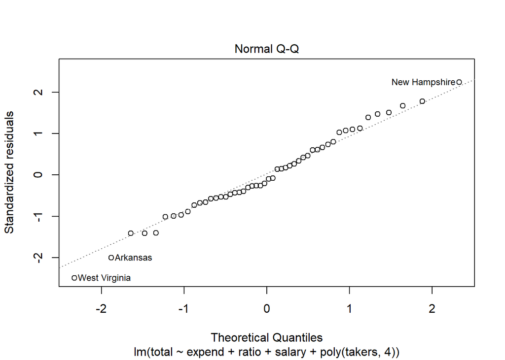

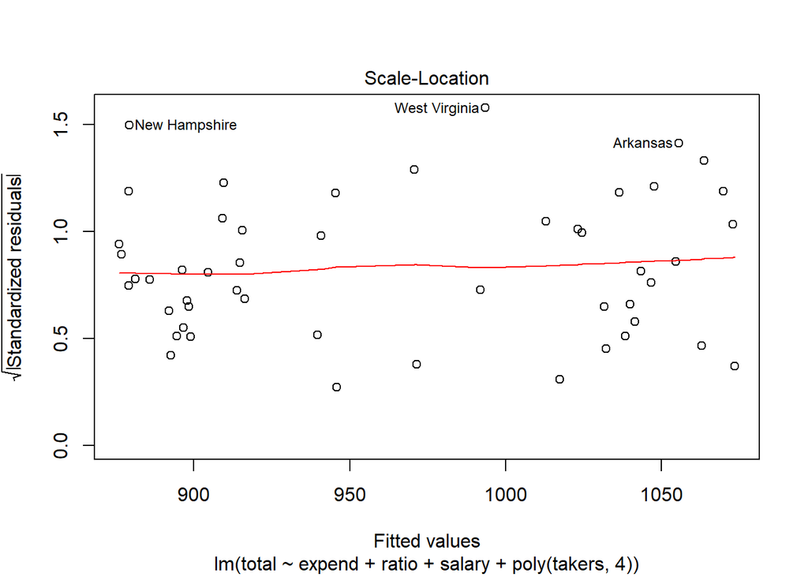

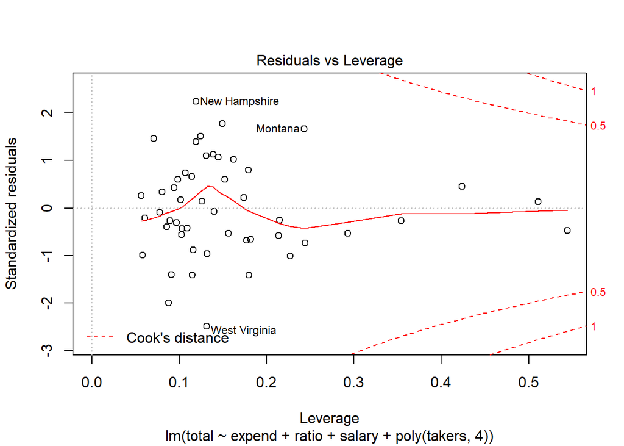

```r
plot(lmod3)
```

Plots Look Much better now.  
r) Now imagine we settled on a model of total vs. salary and takers. Ratio and expend are also in the data set, but we are not using those in the model.  
Setting the seed to 123, create a data set sat2 that has 20 random values of salary set to NA.  
Create a third data set sat3 that is a copy of sat2.  
Use regression to impute the missing values for the salaries predictor in sat3.  
At this point, sat will have the original values, sat2 the missing values, and sat3 the imputed by regression values. Compare some of the imputed values versus the originals; does it seem like the process did a good job?  
Step1: Setting the seed to 123, create a data set sat2 that has 20 random values of salary set to NA.

```r
set.seed(123)
df_containing_approx_20nulls_forAll = as.data.frame(lapply(sat, function(cc) cc[sample(c(TRUE,NA), prob = c(.61,.39), size = length(cc), replace = TRUE)]))
summary(df_containing_approx_20nulls_forAll)
```

```
##      expend          ratio           salary          takers
##  Min.   :3.656   Min.   :13.80   Min.   :25.99   Min.   : 5.00
##  1st Qu.:4.809   1st Qu.:14.95   1st Qu.:31.20   1st Qu.: 9.00
##  Median :5.463   Median :16.25   Median :32.53   Median :30.00
##  Mean   :5.748   Mean   :16.34   Mean   :34.24   Mean   :36.42
##  3rd Qu.:6.148   3rd Qu.:17.20   3rd Qu.:36.64   3rd Qu.:64.00
##  Max.   :9.774   Max.   :24.00   Max.   :47.95   Max.   :81.00
##  NA's   :20      NA's   :20      NA's   :20      NA's   :17
##      verbal           math           total
##  Min.   :406.0   Min.   :454.0   Min.   : 854.0
##  1st Qu.:426.0   1st Qu.:476.2   1st Qu.: 896.0
##  Median :448.0   Median :497.5   Median : 935.0
##  Mean   :455.2   Mean   :511.3   Mean   : 966.4
##  3rd Qu.:487.5   3rd Qu.:540.8   3rd Qu.:1033.0
##  Max.   :516.0   Max.   :592.0   Max.   :1099.0
##  NA's   :20      NA's   :18      NA's   :21
```

```r
sat2 = sat[,-3]
sat2$salary = df_containing_approx_20nulls_forAll$salary
summary(sat2)
```

```
##      expend          ratio           takers          verbal
##  Min.   :3.656   Min.   :13.80   Min.   : 4.00   Min.   :401.0
##  1st Qu.:4.882   1st Qu.:15.22   1st Qu.: 9.00   1st Qu.:427.2
##  Median :5.768   Median :16.60   Median :28.00   Median :448.0
##  Mean   :5.905   Mean   :16.86   Mean   :35.24   Mean   :457.1
##  3rd Qu.:6.434   3rd Qu.:17.57   3rd Qu.:63.00   3rd Qu.:490.2
##  Max.   :9.774   Max.   :24.30   Max.   :81.00   Max.   :516.0
##
##       math           total            salary
##  Min.   :443.0   Min.   : 844.0   Min.   :25.99
##  1st Qu.:474.8   1st Qu.: 897.2   1st Qu.:31.20
##  Median :497.5   Median : 945.5   Median :32.53
##  Mean   :508.8   Mean   : 965.9   Mean   :34.24
##  3rd Qu.:539.5   3rd Qu.:1032.0   3rd Qu.:36.64
##  Max.   :592.0   Max.   :1107.0   Max.   :47.95
##                                   NA's   :20
```

Step2: Create a third data set sat3 that is a copy of sat2.

```r
sat3 = sat2
```

```r
#Making Model for perdiciving missing salary values
lmod_missing_salary = lm(salary~expend+ratio+takers+verbal+math,sat2)
#Cheking model is good enough?
summary(lmod_missing_salary)
```

```
##
## Call:
## lm(formula = salary ~ expend + ratio + takers + verbal + math,
##     data = sat2)
##
## Residuals:
##     Min      1Q  Median      3Q     Max
## -3.8287 -0.8393 -0.0499  1.0798  3.0848
##
## Coefficients:
##             Estimate Std. Error t value Pr(>|t|)
## (Intercept) -2.50231   11.97271  -0.209    0.836
## expend       3.75131    0.38237   9.811 7.13e-10 ***
## ratio        0.83155    0.15478   5.372 1.62e-05 ***
## takers       0.01749    0.03467   0.504    0.619
## verbal      -0.06762    0.05105  -1.324    0.198
## math         0.06215    0.04264   1.458    0.158
## ---
## Signif. codes:  0 '***' 0.001 '**' 0.01 '*' 0.05 '.' 0.1 ' ' 1
##
## Residual standard error: 1.915 on 24 degrees of freedom
##   (20 observations deleted due to missingness)
## Multiple R-squared:  0.8674, Adjusted R-squared:  0.8398
## F-statistic:  31.4 on 5 and 24 DF,  p-value: 8.815e-10
```

```r
#getting the records with NA salary #must be 20
records_with_missing_salary = sat2[is.na(sat3$salary),]
#predicting missing salaries
predicted_missing_salries = predict(lmod_missing_salary , records_with_missing_salary)
predicted_missing_salries
```

```
##       Arkansas       Colorado    Connecticut         Hawaii        Indiana
##       28.45965       34.67591       44.46432       38.61375       35.88010
##           Iowa      Louisiana  Massachusetts        Montana     New Jersey
##       32.63229       29.87085       39.10755       34.09865       48.16897
##     New Mexico       New York North Carolina   North Dakota       Oklahoma
##       29.33885       48.59353       31.48689       30.18754       28.82900
##         Oregon   Pennsylvania   Rhode Island        Vermont        Wyoming
##       39.79895       39.92693       39.00026       35.80854       33.61121
```

```r
#comapring with actual values
sat$salary[is.na(sat2$salary)]
```

```
##  [1] 28.934 34.571 50.045 38.518 36.785 31.511 26.461 40.795 28.785 46.087
## [11] 28.493 47.612 30.793 26.327 28.172 38.555 44.510 40.729 35.406 31.285
```

```r
#Replacing null with the perdicted salary Values
sat3[is.na(sat2[,"salary"]),"salary"] = predicted_missing_salries
#checking Summary
summary(sat3)
```

```
##      expend          ratio           takers          verbal
##  Min.   :3.656   Min.   :13.80   Min.   : 4.00   Min.   :401.0
##  1st Qu.:4.882   1st Qu.:15.22   1st Qu.: 9.00   1st Qu.:427.2
##  Median :5.768   Median :16.60   Median :28.00   Median :448.0
##  Mean   :5.905   Mean   :16.86   Mean   :35.24   Mean   :457.1
##  3rd Qu.:6.434   3rd Qu.:17.57   3rd Qu.:63.00   3rd Qu.:490.2
##  Max.   :9.774   Max.   :24.30   Max.   :81.00   Max.   :516.0
##       math           total            salary
##  Min.   :443.0   Min.   : 844.0   Min.   :25.99
##  1st Qu.:474.8   1st Qu.: 897.2   1st Qu.:31.20
##  Median :497.5   Median : 945.5   Median :34.04
##  Mean   :508.8   Mean   : 965.9   Mean   :34.99
##  3rd Qu.:539.5   3rd Qu.:1032.0   3rd Qu.:38.90
##  Max.   :592.0   Max.   :1107.0   Max.   :48.59
```

s) Compare the summaries of the three models of total vs. salary and takers for the three data sets. Does the imputation by regression do a better job compared to the default (removing the cases)?

```r
#model 1
lmod_with_defualt_values = lm(total~salary+takers,sat)
#model 2
lmod_with_perdicted_missing_values = lm(lm(total~salary+takers,sat3))
#model 3
sat_null_removed = na.omit(sat2)
summary(sat_null_removed)
```

```
##      expend          ratio           takers         verbal           math
##  Min.   :3.656   Min.   :13.80   Min.   : 4.0   Min.   :401.0   Min.   :443.0
##  1st Qu.:4.846   1st Qu.:15.62   1st Qu.: 9.0   1st Qu.:429.2   1st Qu.:480.0
##  Median :5.551   Median :17.00   Median :20.0   Median :454.0   Median :503.5
##  Mean   :5.627   Mean   :17.34   Mean   :30.6   Mean   :460.6   Mean   :511.9
##  3rd Qu.:6.129   3rd Qu.:18.68   3rd Qu.:48.0   3rd Qu.:494.8   3rd Qu.:549.8
##  Max.   :8.963   Max.   :24.30   Max.   :70.0   Max.   :513.0   Max.   :579.0
##      total            salary
##  Min.   : 844.0   Min.   :25.99
##  1st Qu.: 903.8   1st Qu.:31.20
##  Median : 959.5   Median :32.53
##  Mean   : 972.5   Mean   :34.24
##  3rd Qu.:1043.8   3rd Qu.:36.64
##  Max.   :1085.0   Max.   :47.95
```

```r
lmod_null_removes = lm(lm(total~salary+takers,sat_null_removed))
#Comparing Models
summary(lmod_with_defualt_values)
```

```
##
## Call:
## lm(formula = total ~ salary + takers, data = sat)
##
## Residuals:
##     Min      1Q  Median      3Q     Max
## -78.313 -26.731   3.168  18.951  75.590
##
## Coefficients:
##             Estimate Std. Error t value Pr(>|t|)
## (Intercept) 987.9005    31.8775  30.991   <2e-16 ***
## salary        2.1804     1.0291   2.119   0.0394 *
## takers       -2.7787     0.2285 -12.163    4e-16 ***
## ---
## Signif. codes:  0 '***' 0.001 '**' 0.01 '*' 0.05 '.' 0.1 ' ' 1
##
## Residual standard error: 33.69 on 47 degrees of freedom
## Multiple R-squared:  0.8056, Adjusted R-squared:  0.7973
## F-statistic: 97.36 on 2 and 47 DF,  p-value: < 2.2e-16
```

```r
summary(lmod_with_perdicted_missing_values)
```

```
##
## Call:
## lm(formula = lm(total ~ salary + takers, sat3))
##
## Residuals:
##    Min     1Q Median     3Q    Max
## -76.83 -25.75   1.83  20.22  69.33
##
## Coefficients:
##             Estimate Std. Error t value Pr(>|t|)
## (Intercept) 979.1812    34.6350  28.271   <2e-16 ***
## salary        2.3933     1.0886   2.199   0.0329 *
## takers       -2.7528     0.2179 -12.631   <2e-16 ***
## ---
## Signif. codes:  0 '***' 0.001 '**' 0.01 '*' 0.05 '.' 0.1 ' ' 1
##
## Residual standard error: 33.58 on 47 degrees of freedom
## Multiple R-squared:  0.8068, Adjusted R-squared:  0.7986
## F-statistic: 98.16 on 2 and 47 DF,  p-value: < 2.2e-16
```

```r
summary(lmod_null_removes)
```

```
##
## Call:
## lm(formula = lm(total ~ salary + takers, sat_null_removed))
##
## Residuals:
##     Min      1Q  Median      3Q     Max
## -75.361 -27.203   5.581  22.646  73.999
##
## Coefficients:
##              Estimate Std. Error t value Pr(>|t|)
## (Intercept) 1001.3075    48.3329  20.717  < 2e-16 ***
## salary         1.7067     1.4522   1.175     0.25
## takers        -2.8509     0.2889  -9.869 1.88e-10 ***
## ---
## Signif. codes:  0 '***' 0.001 '**' 0.01 '*' 0.05 '.' 0.1 ' ' 1
##
## Residual standard error: 35.78 on 27 degrees of freedom
## Multiple R-squared:  0.7884, Adjusted R-squared:  0.7727
## F-statistic: 50.29 on 2 and 27 DF,  p-value: 7.864e-10
```

Model with predicted missing salaries performs slighty better then the others  
t) Using the data set with missing values (sat2), set the seed to 123 and perform multiple imputation. Compare the regression coefficients and standard errors with those obtained in s.